# CapStoneNewMrkDown

Rekha Vellanki

August 25, 2018

### Brief Description about the data set :

The purpose of EPA’s fuel economy estimates is to provide a reliable basis for comparing vehicles. Most vehicles in this guide (other than plug-in hybrids) have three fuel economy estimates: A city estimate, highway estimate and a combination of city and and highway driving. This data provides annual fuel cost estimates, rounded to the nearest $50 for each vehicle across different makes and models. The data also includes CO2 emissions, and smog ratings that helps evaluate environmental affects based on fuel consumption of vehicles.

The aim of the analysis is to understand the if fuel consumption is influenced by the other variables/elements in the dataset. And to understand if fuel efficient car lines have these variables at a higher proportion. Also to evaluate the environmental effects based on fuel consumption.

### Data wrangling

Data wrangling was done for easier manipulation of the data. The data files are provided by year. Each individual data file is down loaded , saved as csv files to facilitate reading into data frames. The csv files are loaded into data frames. And in this step, the empty values of variables with some missing data are replaced with NA/None for easier data manipulation later. The column names have been renamed for easier understanding. ( Details of the wrangling can be found in data wrangling report https://github.com/royvel/IntroDatSciRprogSpringBoard/blob/master/DataWrangReport-CapstoneProj-RV.docx)

### Exploratory and statistical Analysis

First, examined for distribution of different variables in the data set. Different plots (line, bar, histogram, box) were looked at and finally kept the plots that are easy to read and analyze. As a next step, studied the influence of various variables on fuel consumption (mpg). The key variables studied for this analysis are cylinders, engine displacement, transmission, and drive systems. There are other variables like viscosity, air aspiration methods, valves/valves timing etc in the data set. For the scope of this analysis, looked at variables that are usually looked by consumers while purchase of an vehicle. Examined the fuel consumption across different carlines and manufacturers. Correlation plots of key categorical variables was studied. Examined few scatter plots with liner regression to understand the correlation.

##### Cylinders

Most cars have 4,6,8 cylinders, highest being 4 cylinder cars. As this data set is all about fuel usage, interesting to see how the number of cylinders are in correlation with uel consumption. Are the 4 cylinder cars higher in number b’coz they are fuel efficient?

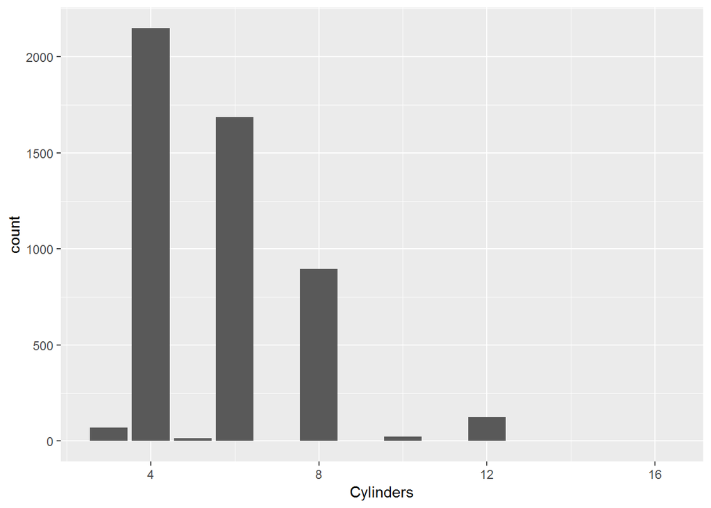

##### Engine Displacement

Majority of cars Engine displacement ranging from 2 to 3.5. Higher the cylinders, higher is the engine displacement in general. So expecting cylinders and displacement are correlated to fuel consumption in similar way.

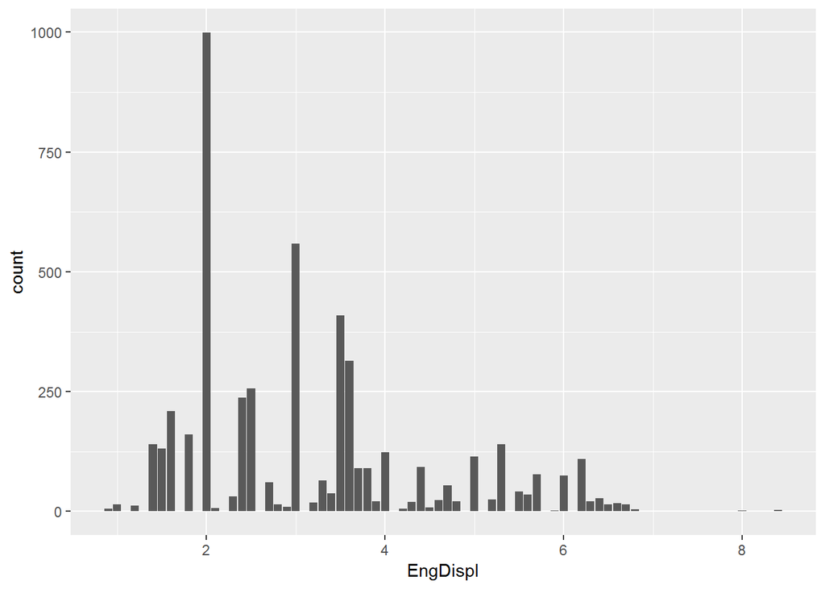

##### Transmission

Semi automatic cars are higher in number followed by automatic and manual. How is the distribution of cylinders with these transmission and how does it impact the fuel consumption ?

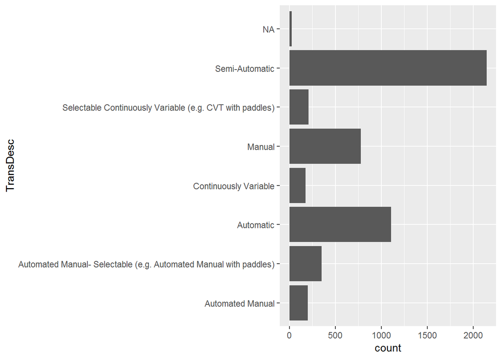

##### Drives

2 wheel drive and All wheel drive are higher than 4 wheel drive cars. Is 2 wheel drive more popular b’coz of the higher mpg it gives ? And the drive system distribution within the carlines need to be looked at to completely understand the impact on fuel efficiency.

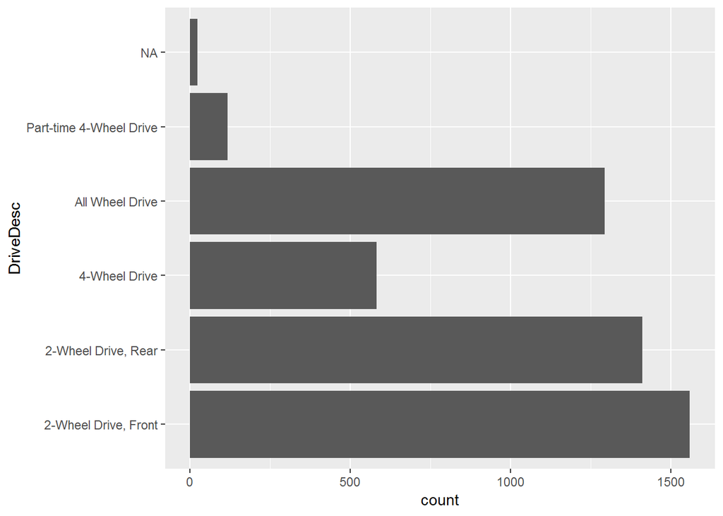

#### Carlines

Midsize and compact cars are the most driven cars. Next in line are subcompact and small suv’s. There are several factors influencing this distribution but will look at how the mpg varies between the car lines.

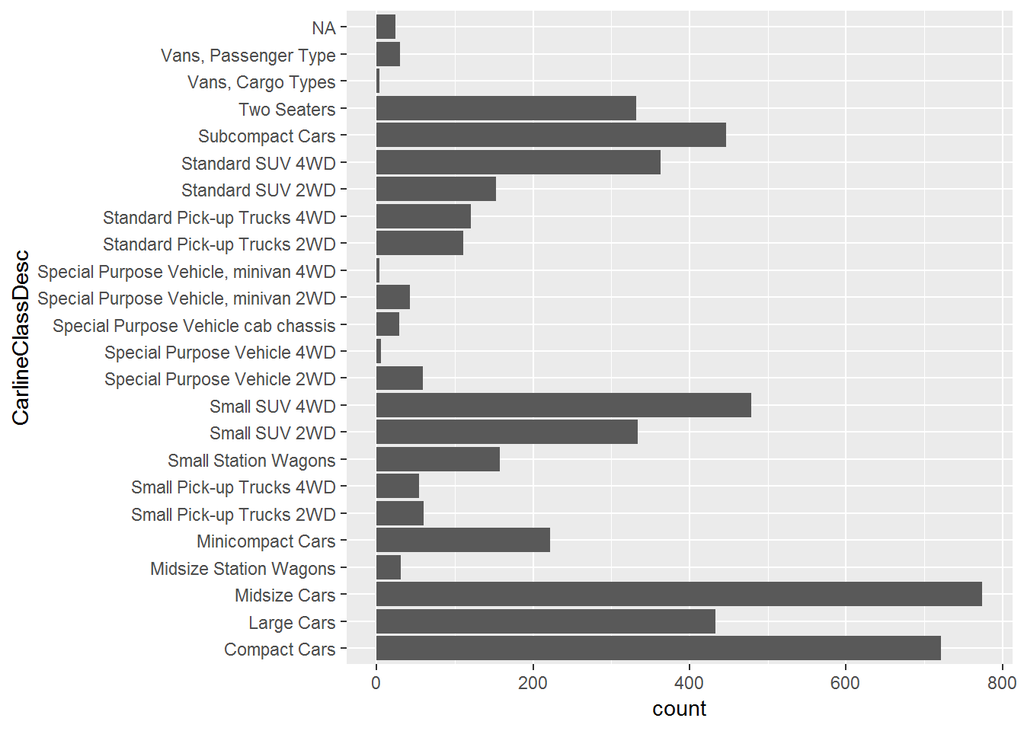

#### Relation of variables on fuel consumption

The plot shows that as the number of cylinders increases, the city fuel efficiency decreases. In other words, lower the cylinders, the better is the fuel consumption. So it looks like there is a negative correlation on fuel efficiency with increase in number of cylinders. To understand the extent of significance , statistical analysis is run on these 2 variables and plots are shown in the later part.

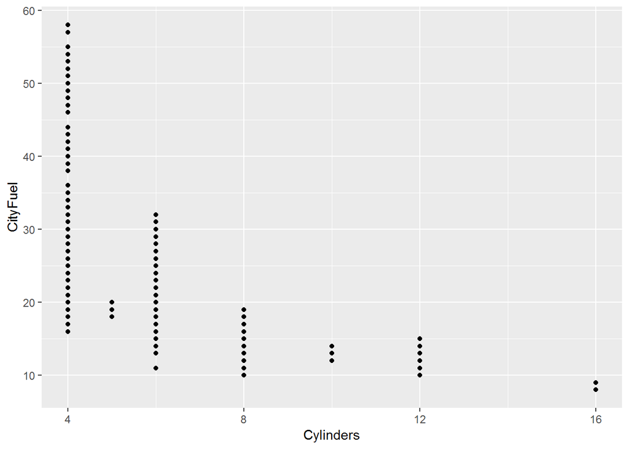

#### impact of transmission type on cityfuel

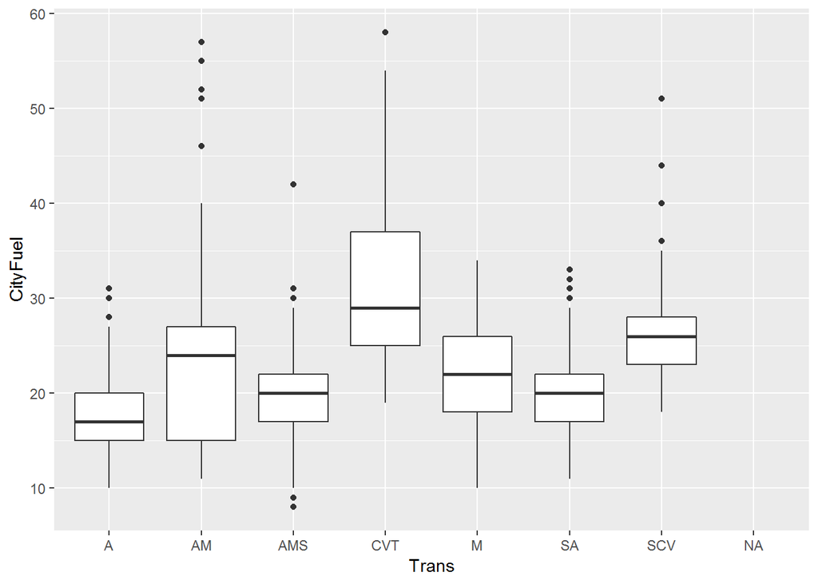

##### carlineclassdesc and cityfuel

Order of better fuel consumption, from highest to lowest - Small station wagons, compact cars, small suvs, mini cars, suvs and trucks. So, small station wagons followed by compact cars give better miles per gallon.

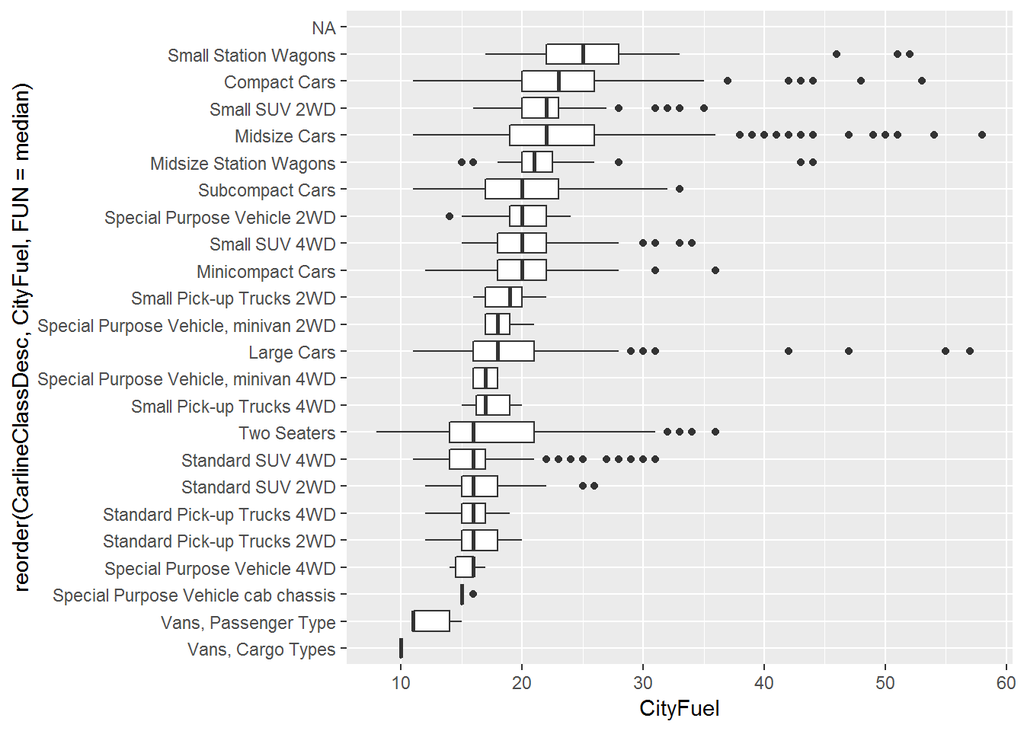

##### impact of DriveSys on cityfuel

2 wheel front drive cars have better mpg than other drive systems. All wheel drive vehicles are the next fuel efficient. So, to get better fuel usage, the better option is a 2 wheel front drive.

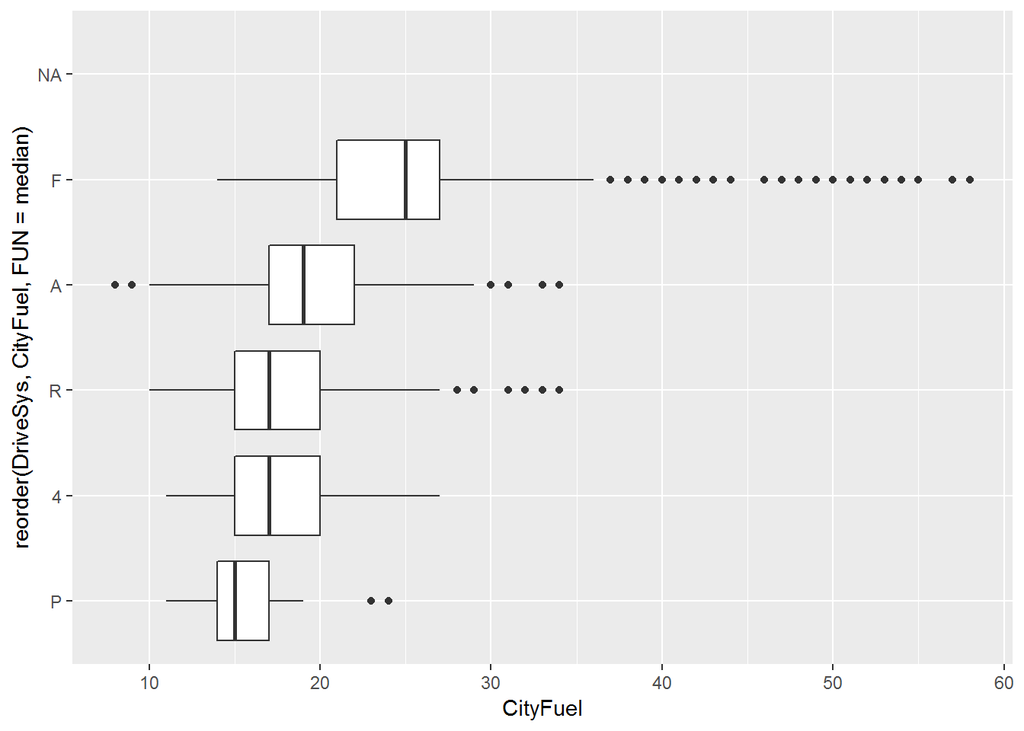

###### multivariable distribution

#### Carline and DriveDesc

Below plot shows the distribution of drive system withing each car line. As you saw above, 2 wheel drive front has higher fuel efficiency. And, compact, small suv’s and midsize are more fuel efficient cars. The plot below shows that the fuel efficient car lines comprise of more 2 wheel drive front drive systems.

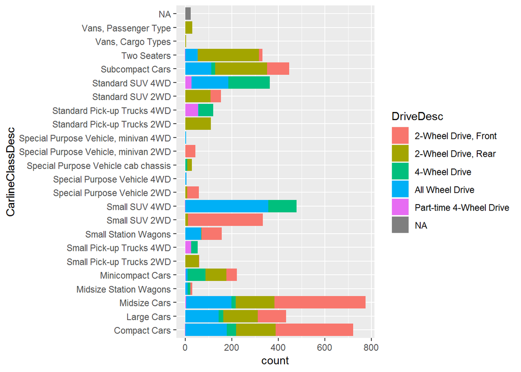

###### Carline and Cylinders

Below plot shows the distribution of Cylinders withing each car line. As you saw above, lower number of cylinders has higher fuel efficiency. And, compact, small suv’s and midsize are more fuel efficient cars. The plot below shows that distribution of 4 cylinders are higher in compact, midsize and small suv’s.

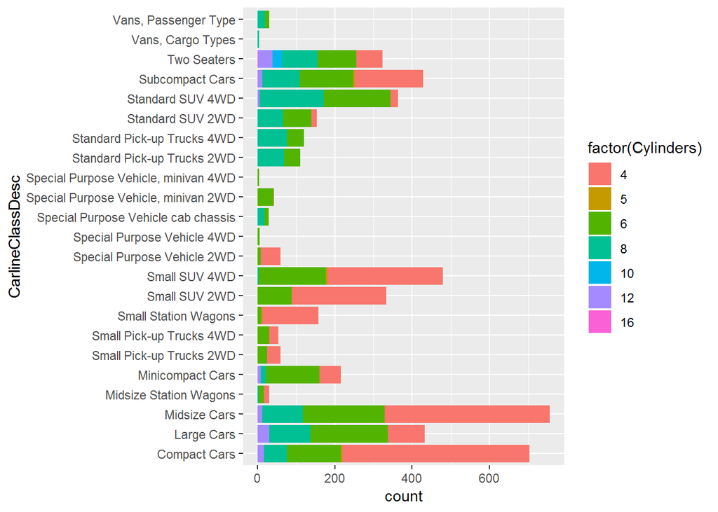

##### fuel consumption and Green House Rating

(GHG 1-10 , 10 being good rating) Higher fuel economy is associated with better GHG emissions and better GHG rating. So cars with higher miles per gallon are more environmental friendly.

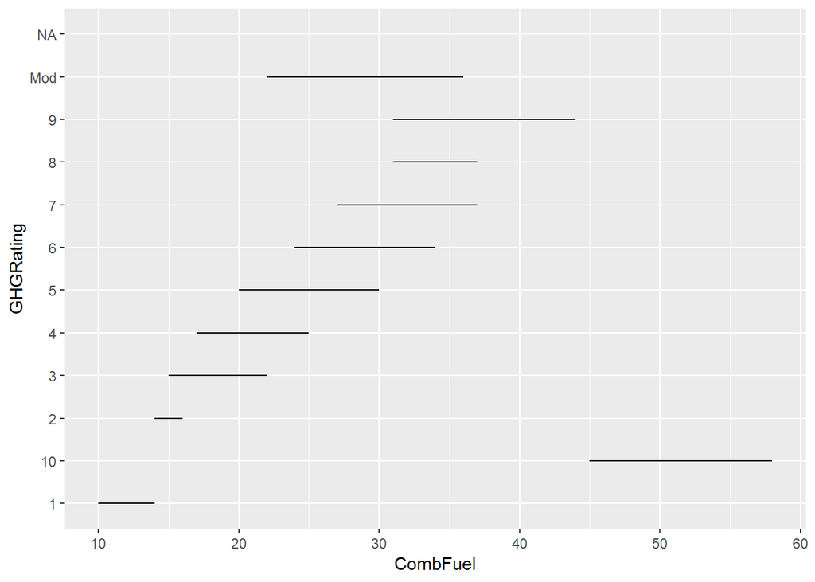

#### linear regression of cylinders and Cityfuel.

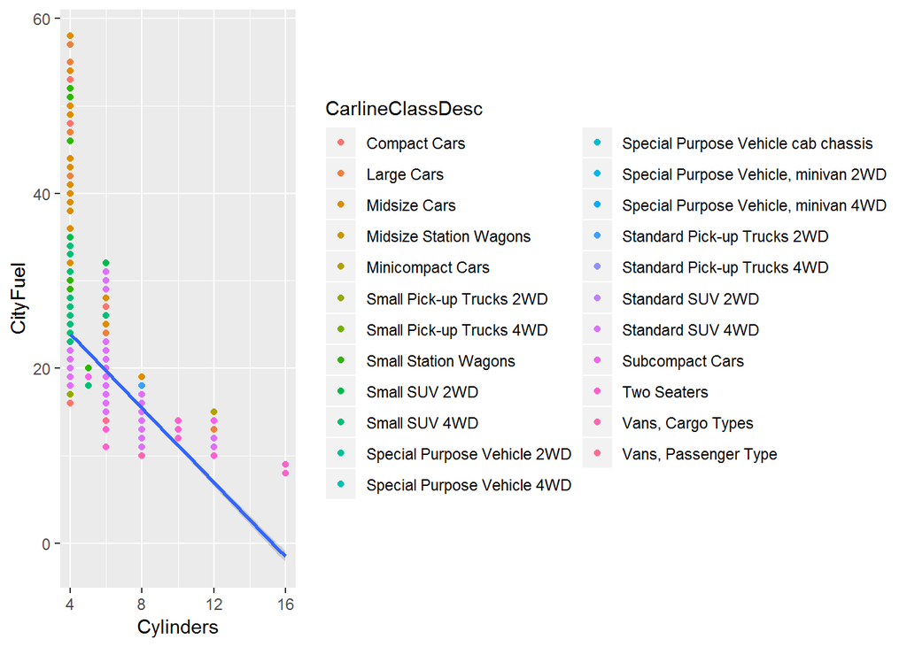

Finding correlations between different variables.

Key observations are cylinders having moderate -ve correlation with fuel consumption , i.e higher the number of cylinders, lower the fuel efficiency. So, cars with lower number of cylinders give more mile per gallon.

Cylinders and engine displacement show positive correlation. So, Engine displacement correlation to city fuel is similar to Cylinders. Higher the engine displacement, lower is the fuel efficiency.

city fuel and annual fuel cost show moderate to good -ve correlation. The fuel cost spent on cars with higher mile per gallon is lower than fuel cost spent on cars with lower miles per gallon.

City fuel and GHG rating show moderate positive correlation. Higher the mile per gallon, higher the GHG rating (lower the emissions). Higher GHG rating is better for the environment.

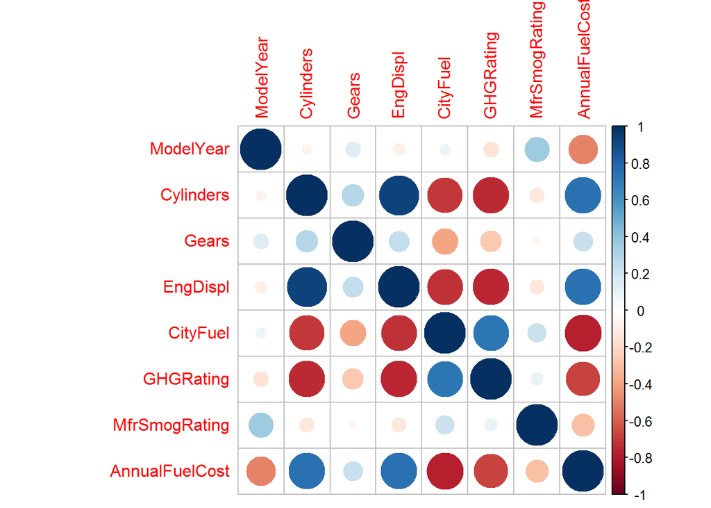

###### LM of all variables on mpg

The model is to predict the impact of multiple variables on city fuel (mpg). The variables included in the model are cylinders, engine displacment, gears, drive systems and transmission type.

The significant codes(asterisks) indicate that its very likely that the chosen variables have an impact on the dependent variable. But we need to see how significant it is. As the output shows, the chosen multiple variables explain 68.7% observed variance on the dependent variable city fuel.

```
##
## Call:
## lm(formula = CityFuel ~ Cylinders + EngDispl + Gears + DriveSys +
##     Trans, data = mydatafc)
##
## Residuals:
##      Min       1Q   Median       3Q      Max
## -10.5879  -1.6749  -0.1255   1.1814  29.0117
##
## Coefficients:
##              Estimate Std. Error t value Pr(>|t|)
## (Intercept) 25.661404   0.408095  62.881  < 2e-16 ***
## Cylinders   -0.520644   0.067450  -7.719 1.41e-14 ***
## EngDispl    -1.761858   0.095819 -18.387  < 2e-16 ***
## Gears        0.229825   0.048211   4.767 1.92e-06 ***
## DriveSysA    0.008563   0.171797   0.050 0.960250
## DriveSysF    2.769478   0.177123  15.636  < 2e-16 ***
## DriveSysP   -0.919659   0.328437  -2.800 0.005128 **
## DriveSysR    0.528070   0.159981   3.301 0.000971 ***
## TransAM      3.079995   0.252988  12.174  < 2e-16 ***
## TransAMS     0.718489   0.200663   3.581 0.000346 ***
## TransCVT     8.980610   0.380991  23.572  < 2e-16 ***
## TransM       0.630784   0.165687   3.807 0.000142 ***
## TransSA     -0.083671   0.129610  -0.646 0.518594
## TransSCV     4.810432   0.247810  19.412  < 2e-16 ***
## ---
## Signif. codes:  0 '***' 0.001 '**' 0.01 '*' 0.05 '.' 0.1 ' ' 1
##
## Residual standard error: 3.148 on 4952 degrees of freedom
##   (24 observations deleted due to missingness)
## Multiple R-squared:  0.6876, Adjusted R-squared:  0.6868
## F-statistic: 838.3 on 13 and 4952 DF,  p-value: < 2.2e-16
```